# Exploratory Analysis

## Project title: Health Systems Across the World

### Authors

Megana Shivakumar

Jorey Papritz

Victoria Cervantes

Sabriyah Morshed

### Date

Winter 2022

### Abstract

In this project, we question the relationship(s) between global healthcare systems and healthcare expenditure. Understanding this is important because it allows us to find the best way to finance healthcare and optimize its delivery across the world. To answer this question, we plan on analyzing data from the World Bank, taking into consideration the limitations and biases present in the dataset.

### Keywords

Healthcare / World Bank / Population Health / Healthcare Spending

### Introduction

Broadly, we want to understand the trends in healthcare spending globally. We strive to answer the question of whether there is a relationship between the number of healthcare personnel and money spent on healthcare. Some questions to guide our research include:

- Does the amount of health expenditure affect the amount of health workers and their overall effectiveness?
- Is the amount of healthcare spending correlated with the number of available physicians and nurses?
- Is the percentage of GDP attributable to healthcare associated with an increase or decrease in available healthcare workers?

The dataset that we have agreed to use for this project is an assimilation of *World Development Indicators: Health Systems* (2.12) created by the World Bank. One limitation of our dataset is that the data from each column is collected from a different time frame. To mitigate this, we were planning on analyzing data from one year that is included in each timeframe (EX: 2018). An additional limitation is that we felt that COVID-19 was a large contributor to modern trends in healthcare systems. This dataset cannot accurately describe the current state of healthcare, but we believe that we can get an accurate enough picture of the situation to answer our proposed research questions. Interpreting this data set can provide us with insights as to whether higher healthcare expenditure truly does mean access to higher quality healthcare.

### Related Work

Related works have focused on analyzing how healthcare spending affects the overall health of a population. This work is important to do as it can be used to create new health policies that can be used to help lower income countries build better healthcare systems. In addition, understanding the number of [healthcare workers per capita](https://www.bmj.com/content/357/bmj.j2940) can be influential in analyzing the quality of healthcare within different countries. The quality of healthcare should be maintained at a high level even in countries with a lower level of healthcare spending, and understanding how some countries are able to keep this balance is important. The [World Bank](https://data.worldbank.org/indicator/SH.XPD.CHEX.GD.ZS) is an important factor in trying to create a world that is free of poverty by analyzing the ways in which countries are able to keep healthcare spending at a reasonable level while also maintaining the health of their country. [Various analyses](https://www.healthsystemtracker.org/chart-collection/health-spending-u-s-compare-countries-2/) looking at the countries that spend the most vs. the least amount of money on healthcare, number of doctors per capita, and percentage of GDP spent on healthcare, we are able to learn how global healthcare can be improved to decrease poverty levels across the world. These methods help create a more equitable world.

**References**  
Current health expenditure (% of GDP). Data. (n.d.). Retrieved February 3, 2023, from https://data.worldbank.org/indicator/SH.XPD.CHEX.GD.ZS  
Moberly, T. (2017, June 20). UK has fewer doctors per person than most other OECD countries. The BMJ. Retrieved February 3, 2023, from https://www.bmj.com/content/357/bmj.j2940  
Twitter, E. W., Twitter, E. W., Ortaliza, J., & Twitter, C. C. (2022, February 14). How does health spending in the U.S. compare to other countries? Peterson-KFF Health System Tracker. Retrieved February 3, 2023, from https://www.healthsystemtracker.org/chart-collection/health-spending-u-s-compare-countries-2/  
World development indicators: The World Bank. World Development Indicators | The World Bank. (n.d.). Retrieved February 3, 2023, from http://wdi.worldbank.org/table/2.12#

### The Dataset

The World Bank as part of the World Development Indicators for 2016 database collected the data. This [data](https://www.kaggle.com/datasets/danevans/world-bank-wdi-212-health-systems) was collected by the World Bank who gathered data “by the Bank’s country management units and data obtained from official sources.” The World Bank collects data with the goal of achieving a world without poverty while trying to improve the quality and quantity of data. There are 211 observations in the data across 14 features. The data that we are utilizing comes from the World Bank, an international financial institution, so we need to be careful with bias in the dataset. The data might not be representative of a population as a whole. An institution that collects data like this cannot be 100% accurate so we have to look at the data with a sharp view. Some countries might have more access to healthcare workers but less money, and vice versa. We have to examine our bias when conducting our own analysis on the data. We have to make sure that when we present our data we are doing it in the least biased and most fair way possible. Some possible limitations of this data are the lack of data about COVID-19 health expenditures. It’s not as modern as we would like the data to be.

### Implications

The possible implications of this analysis are to understand healthcare spending as it differs from one country to another. This information can be important as it can show how healthcare spending affects the overall health of a population. In addition, we gain insight into how the number of doctors per capita affects healthcare spending, and whether higher or lower spending relates to better or worse health for the overall population of that country. In addition, relating healthcare spending to healthcare efficacy, we are able to learn detailed information about if spending truly impacts how effective healthcare really is. Overall, the ideas that we learn from these analyses can be influential for public health policy implementation. Learning about the effects of healthcare spending and healthcare workers per capita can be helpful in lower income countries, where there may be a lower amount of spending on healthcare, but still have a need for high quality healthcare.

### Limitations & Challenges

One of the main challenges that we noticed within this dataset was that some of the data was collected within different years, so it may be difficult to compare data that was collected at different time points. One of the solutions we have for this is to create different graphs that look at different time periods, for example only comparing data from columns that were collected within the same year. In addition, our dataset only contains data collected up to 2016. We have no information about how the Covid - 19 pandemic has affected healthcare spending and healthcare workers, and we believe that this pandemic would have a massive impact on healthcare spending and overall GDP. Another aspect of this dataset that could be a challenge is the quality of the dataset, and how not having all the information and data for every country could lead to bias. We aim to prevent this by carefully thinking about how the analyses we run can impact the outputs and providing a disclaimer within our visualizations.

### Summary Information

The summary information R script contains valuable information about the contents of our data. Overall, there are 210 rows in our data set, indicating the 210 countries that are included as part of this World Bank data. In addition, the highest and lowest levels of current health expenditure expressed as a percentage of GDP is 23.3% as the maximum and 1.7% at a minimum in Monaco. In addition, another aspect of this data that we want to explore is the populations of healthcare workers in respect to the overall country population. We found that the maximum number of doctors per 1,000 people is 8.2, while the minimum is 0 physicians per 1,000 people, which we interpret to mean that this ratio is so small that there is only 1 doctor for a larger section of the population.

### Chart 1

Question: Does the amount of health expenditure affect the amount of health workers and their overall effectiveness?

This bubble plot chart shows the relationship between health expenditure per capita, nurse/midwife density, completeness of birth registration, and completeness of death registration. We can make some observations according to this data: -Countries with higher health expenditure per capita generally have higher nurse/midwife density. -It does not appear that there is a clear relationship between health expenditure per capita and completeness of birth registration. -There is a slight positive relationship between health expenditure per capita and completeness of death registration, with countries with higher health expenditure having higher completeness of death registration. Overall, the plot is clear that health expenditure per capita is associated with higher nurse/midwife density, but for completeness of birth and death registration, it is less clear.

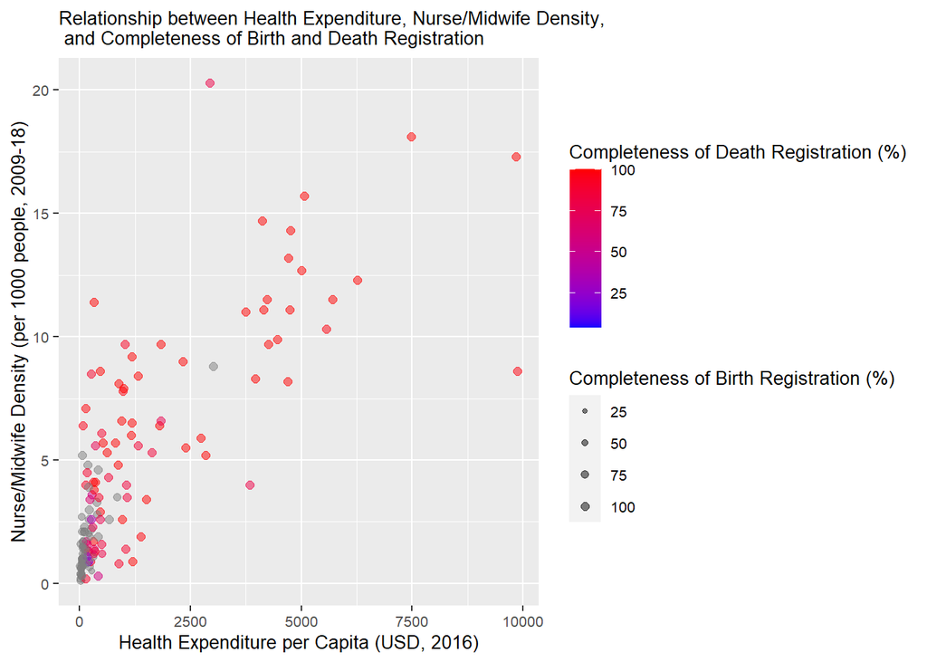

### Chart 2

Scatter plot: for the relationship between healthcare spending and the number of available physicians and nurses

I decided to use this chart to see the correlation between healthcare spending and physician availability. It might seem obvious that a higher number of physicians would be associated with increased healthcare spending, but there is more to this visualization than just that. We can explore some deeper questions such as: 1. Where exactly is the money being spent on healthcare going? 2. Does more spending always mean more physicians and nurses?

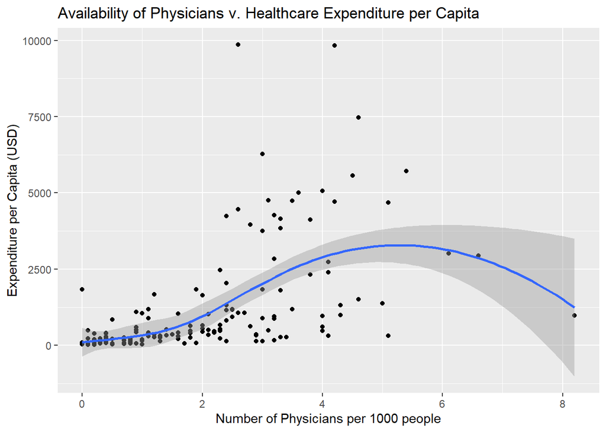

### Chart 3

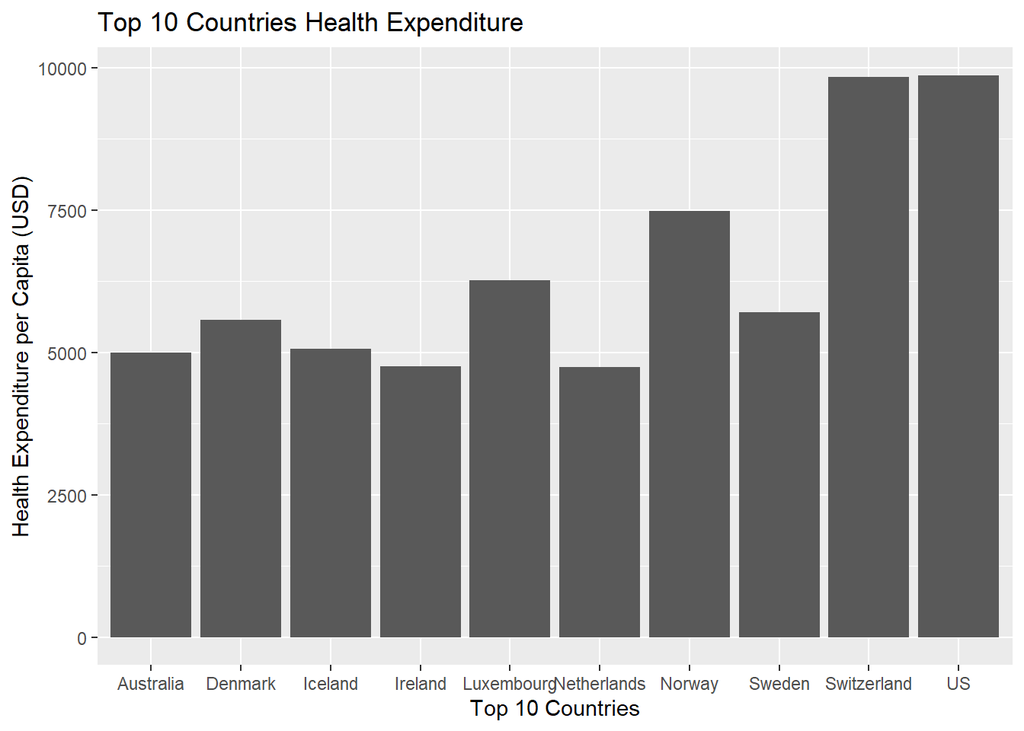